# LMM: Random effects

2018-05-15

## Mixed-effects models

- 4.0 Introduction to LMM
- 4.1 Random effects
- 4.2 Solving LM problems using LMM
- 4.3 A showcase of some useful applications
- 4.4 Introduction to GLMM
- 4.5 More complex mixed models

## You will learn in this session

- when to consider effects as fixed or random
- that REML fits are best to study variances
- how to implement different random effects structure
- what random slopes are

## To mix or not to mix?

## Choosing between fixed and random effects

The choice between considering a predictor has having fixed or random effects can be difficult; it depends on the trade-off between the pros and cons of both approaches.

### Fixed effects

- no assumption about the distribution of the effects associated with each level of a predictor
- requires many new datapoints for each additional levels to get reliable results
- allows for the prediction of the effect of observed levels only (for factors)
- simple to study

### Random effects

- the effects associated with each level of a predictor follow a given probability distribution
- requires at least one new datapoint for each additional levels to get reliable results (more is better)
- requires many levels for the variance estimates to be reliable (5 being strict minimum)
- allow for the prediction of the effect of both observed and unobserved levels (for factors)
- more difficult to study

## Studying variation using LMM

## Estimating a variance

### Let's simulate a dataset under the assumptions of LMM

```r
set.seed(1)
Aliens <- simulate_Mix(intercept = 50, slope = 1.5, n = 30, group_nb = 10, var.rand = 2, var.error = 0.5)
```

## Estimating a variance

- Estimating variance components and estimating BLUPS are the only situation in which parameters must be fitted to the data by REstricted (or REsidual) Maximum Likelihood instead of Maximum Likelihood.
- A ML fit would lead to underestimate the variances.

Note:

- different packages and different functions within the same package may have ML or REML as a default fitting method, so always double check!
- unlike ML, REML is sensitive to changes in contrasts.

## Estimating a variance

### Model fit with `lmer` (`REML = TRUE` by default)

```r
library(lme4)
(mod <- lmer(y ~ x + (1|group), data = Aliens))
```

```
## Linear mixed model fit by REML ['lmerMod']
## Formula: y ~ x + (1 | group)
##    Data: Aliens
## REML criterion at convergence: 82.6679
## Random effects:
##  Groups   Name        Std.Dev.
##  group    (Intercept) 1.2385
##  Residual             0.6819
## Number of obs: 30, groups:  group, 10
## Fixed Effects:
## (Intercept)            x
##      50.103        1.394
```

## Estimating a variance

### Model fit with `fitme`

```r
library(spaMM)
(mod2 <- fitme(y ~ x + (1|group), data = Aliens, method = "REML"))
```

```
## formula: y ~ x + (1 | group)
## REML: Estimation of lambda and phi by REML.
##       Estimation of fixed effects by ML.
## Family: gaussian ( link = identity )
##  ------------ Fixed effects (beta) ------------
##             Estimate Cond. SE t-value
## (Intercept)   50.103   0.4940 101.417
## x              1.394   0.5546   2.514
##  --------------- Random effects ---------------
## Family: gaussian ( link = identity )
##            --- Variance parameters ('lambda'):
## lambda = var(u) for u ~ Gaussian;
##    group  :  1.534
##              --- Coefficients for log(lambda):
##  Group        Term Estimate Cond.SE
##  group (Intercept)   0.4279   0.501
## # of obs: 30; # of groups: group, 10
##  ------------- Residual variance  -------------
## Coefficients for log(phi) ~ 1 :
##             Estimate Cond. SE
## (Intercept)  -0.7656    0.316
## Estimate of phi=residual var:  0.465
##  ------------- Likelihood values  -------------
##                         logLik
## p_v(h) (marginal L): -41.70110
##   p_beta,v(h) (ReL): -41.33393
```

## Distribution of the variance estimate

```r
lambdas_large <- replicate(1000, {
  d <- simulate_Mix(intercept = 50, slope = 1.5, n = 30, group_nb = 10, var.rand = 10, var.error = 0.5)
  mod <- fitme(y ~ x + (1|group), data = d, method = "REML")
  as.numeric(mod$lambda)
})
```

```r
lambdas <- replicate(1000, {
  d <- simulate_Mix(intercept = 50, slope = 1.5, n = 30, group_nb = 10, var.rand = 2, var.error = 0.5)
  mod <- fitme(y ~ x + (1|group), data = d, method = "REML")
  as.numeric(mod$lambda)
})
```

```r
lambdas_small <- replicate(1000, {
  d <- simulate_Mix(intercept = 50, slope = 1.5, n = 30, group_nb = 10, var.rand = 0.1, var.error = 0.5)
  mod <- fitme(y ~ x + (1|group), data = d, method = "REML")
  as.numeric(mod$lambda)
})
```

## Distribution of the variance estimate

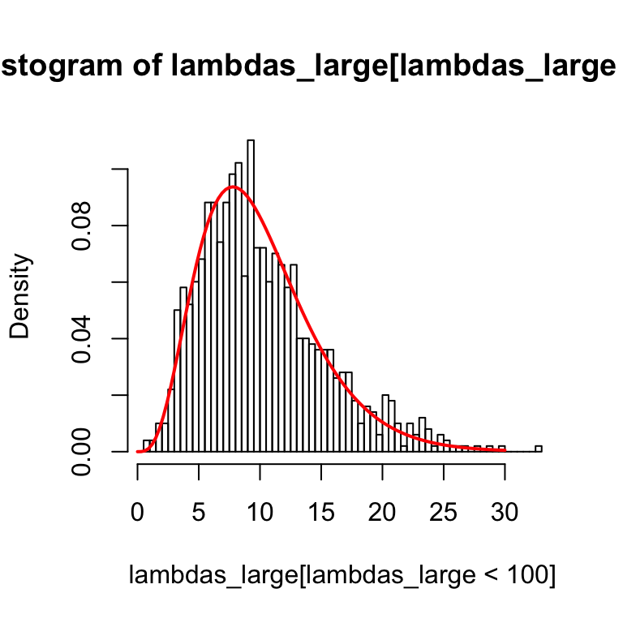

```r
var.between.group <- 10
hist(lambdas_large[lambdas_large < 100], nclass = 50, probability = TRUE)
shape <- (10 - 1)/2 ## with 10 being the number of levels
scale <- (2*var.between.group)/(10 - 1)
curve(dgamma(x, shape = shape, scale = scale), from = 0, to = 30, add = TRUE, lwd = 2, col = "red")
```

## Distribution of the variance estimate

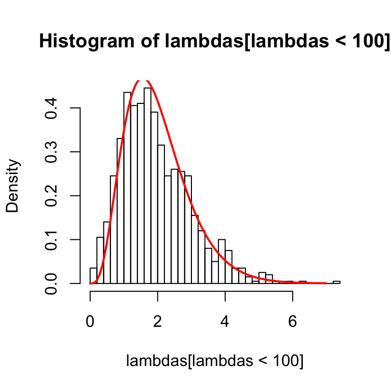

```r
var.between.group <- 2
hist(lambdas[lambdas < 100], nclass = 50, probability = TRUE)
shape <- (10 - 1)/2 ## with 10 being the number of levels
scale <- (2*var.between.group)/(10 - 1)
curve(dgamma(x, shape = shape, scale = scale), from = 0, to = 7, add = TRUE, lwd = 2, col = "red")
```

## Distribution of the variance estimate

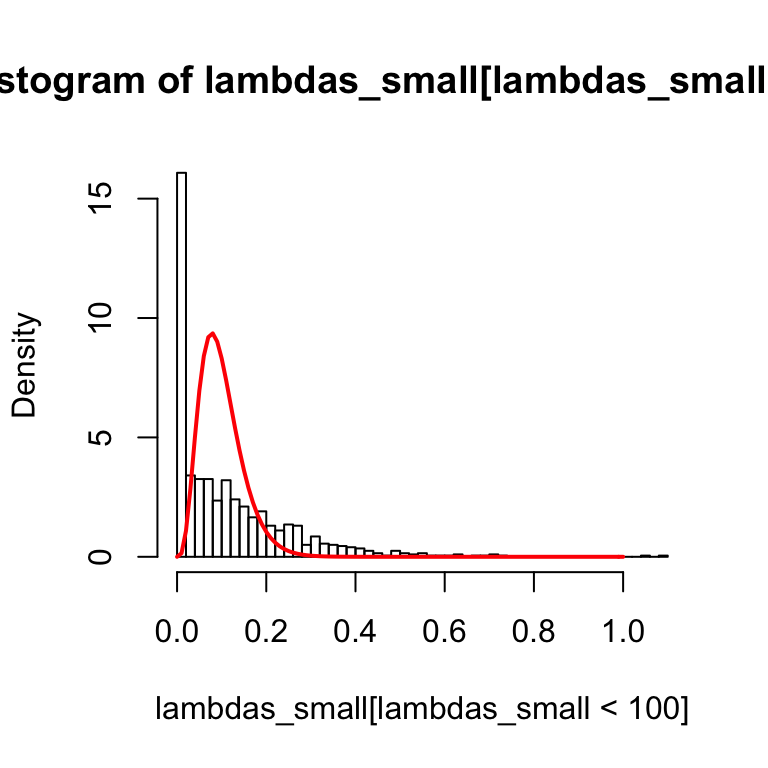

```r
var.between.group2 <- 0.1
hist(lambdas_small[lambdas_small < 100], nclass = 50, probability = TRUE)
shape <- (10 - 1)/2 ## with 10 being the number of levels
scale <- (2*var.between.group2)/(10 - 1)
curve(dgamma(x, shape = shape, scale = scale), from = 0, to = 1, add = TRUE, lwd = 2, col = "red")
```

## Testing the variance

### Model fit with `fitme`

```r
mod2_REML <- fitme(y ~ x + (1|group), data = Aliens, method = "REML")
mod2_H0_REML <- fitme(y ~ x, data = Aliens, method = "REML")
pchisq(2*(logLik(mod2_REML)[[1]] - logLik(mod2_H0_REML)[[1]]), df = 1, lower.tail = FALSE)
```

```
## [1] 3.467907e-05
```

```r
mod2_H2_REML <- fitme(y ~ x + (1|group), data = Aliens, method = "REML", fixed = list(lambda = 2))
pchisq(2*(logLik(mod2_REML)[[1]] - logLik(mod2_H2_REML)[[1]]), df = 1, lower.tail = FALSE)
```

```
## [1] 0.6305182
```

Note 1: this asymptotic test is poor when the variance is low.

Note 2: `spaMM` allows for testing difference with a specific value.

Note 3: `anova()` from `spaMM` will not run in this case.

## Testing the variance

### Model fit with `lmer`

```r
mod_REML <- lmer(y ~ x + (1|group), data = Aliens, REML = TRUE)
mod_H0 <- lm(y ~ x, data = Aliens)
pchisq(2*(logLik(mod_REML)[[1]] - logLik(mod_H0)[[1]]), df = 1, lower.tail = FALSE)
```

```
## [1] 2.778117e-05
```

```r
anova(mod_REML, mod_H0)
```

```
## refitting model(s) with ML (instead of REML)
```

```
## Data: Aliens
## Models:
## mod_H0: y ~ x
## mod_REML: y ~ x + (1 | group)
##          Df     AIC     BIC  logLik deviance  Chisq Chi Df Pr(>Chisq)
## mod_H0    3 106.232 110.435 -50.116  100.232
## mod_REML  4  91.316  96.921 -41.658   83.316 16.916      1  3.908e-05 ***
## ---
## Signif. codes:  0 '***' 0.001 '**' 0.01 '*' 0.05 '.' 0.1 ' ' 1
```

Note: `lme4` does not allow for testing difference with a specific value.

## Reliability of the test

```r
test <- replicate(1000, {
  d <-  simulate_Mix(intercept = 50, slope = 1.5, n = 30, group_nb = 10, var.rand = 2, var.error = 0.5)
  mod <- fitme(y ~ x + (1|group), data = d, method = "REML")
  mod0 <- fitme(y ~ x + (1|group), data = d, method = "REML",
                fixed = list(lambda = 2))
  pchisq(2*(logLik(mod) - logLik(mod0)), df = 1, lower.tail = FALSE)
})
```

## Reliability of the test

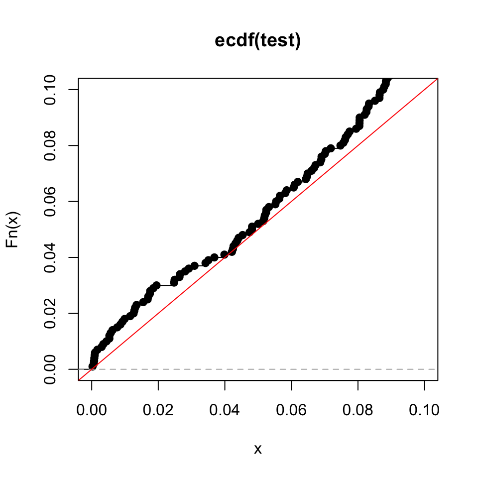

```r
plot(ecdf(test), xlim = c(0, 0.1), ylim = c(0, 0.1))
abline(0, 1, col = "red")
```

## Reliability 2 (small variance)

```r
test2 <- replicate(1000, {
  d <-  simulate_Mix(intercept = 50, slope = 1.5, n = 30, group_nb = 10, var.rand = 0.1, var.error = 0.5)
  mod <- fitme(y ~ x + (1|group), data = d, method = "REML")
  mod0 <- fitme(y ~ x + (1|group), data = d, method = "REML",
                fixed = list(lambda = 0.1))
  pchisq(2*(logLik(mod) - logLik(mod0)), df = 1, lower.tail = FALSE)
})
```

## Reliability 2 (small variance)

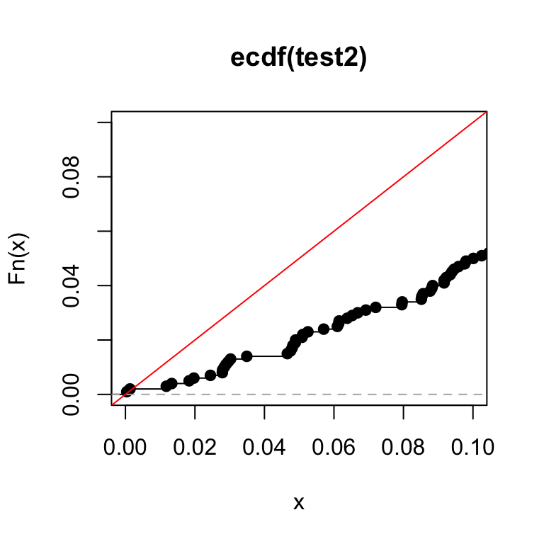

```r
plot(ecdf(test2), xlim = c(0, 0.1), ylim = c(0, 0.1))
abline(0, 1, col = "red")
```

Likelihood ratio tests never work well close to parameter boundaries… (better use parametric bootstrap!)

## Testing variance using parametric bootsrap

### Based on the models fitted with `lme4`

```r
set.seed(1L)
(LRTobs <- 2*(logLik(mod_REML)[[1]] - logLik(mod_H0)[[1]]))
```

```
## [1] 17.56391
```

```r
LRTH0 <- replicate(200, {
                    Aliens$y <- simulate(mod_H0)[, 1]
                    2*(logLik(lmer(y ~ x + (1|group), data = Aliens, REML = TRUE))[[1]] -
                      logLik(lm(y ~ x, data = Aliens))[[1]])
                    })
(sum(LRTH0 >= LRTobs) + 1) / (length(LRTH0) + 1)
```

```
## [1] 0.004975124
```

Note using update creates problems here…

## Testing variance using parametric bootsrap

### Based on the models fitted with `spaMM`

```r
set.seed(1L)
(LRTobs <- 2*(logLik(mod2_REML)[[1]] - logLik(mod2_H0_REML)[[1]]))
```

```
## [1] 17.14242
```

```r
LRTH0_bis <- replicate(200, {
                    Aliens$y <- simulate(mod2_H0_REML)
                    2*(logLik(fitme(y ~ x + (1|group), data = Aliens, method = "REML"))[[1]] -
                      logLik(fitme(y ~ x, data = Aliens, method = "REML"))[[1]])
                    })
(sum(LRTH0 >= LRTobs) + 1) / (length(LRTH0) + 1)
```

```
## [1] 0.004975124
```

## Confidence interval for the variance with `lme4`

```r
mod_lmer <- lmer(y ~ x + (1|group), data = Aliens, REML = TRUE)
round(confint(mod_lmer, method = "profile")[1, ]^2, 2)  ## more at ?lme4:::confint.merMod
```

```
## Computing profile confidence intervals ...
```

```
##  2.5 % 97.5 %
##   0.51   4.14
```

```r
round(confint(mod_lmer, method = "boot", nsim = 1000)[1, ]^2, 2)
```

```
## Computing bootstrap confidence intervals ...
```

```
##  2.5 % 97.5 %
##   0.36   3.45
```

Note: there is not yet an alternative for `spaMM` but you can use `boot` as we did for LM!

## Confidence interval for the variance using `spaMM + boot`

```r
library(boot)
n_boot <- 1000
newYs <- simulate(mod2_REML, type = "marginal", nsim = n_boot)
```

```
## Unconditional simulation:
```

```r
res_sim <- sapply(1:n_boot, function(i) {
  Aliens$y <- newYs[, i]
  log(fitme(y ~ x + (1|group), data = Aliens, method = "REML")$lambda[[1]])}) ## lambda on new data
exp(boot.ci(boot.out = list(R = n_boot),
        t0 = log(fitme(y ~ x + (1|group), data = Aliens, method = "REML")$lambda[[1]]), ## original lambda
        t  = matrix(res_sim, ncol = 1), type = "basic")$basic[, 4:5])
```

```
##
## 0.658194 8.371460
```

## Specifying multiple random effects

## The `lme4::Penicillin` dataset

```r
str(Penicillin)
```

```
## 'data.frame':    144 obs. of  3 variables:
##  $ diameter: num  27 23 26 23 23 21 27 23 26 23 ...
##  $ plate   : Factor w/ 24 levels "a","b","c","d",..: 1 1 1 1 1 1 2 2 2 2 ...
##  $ sample  : Factor w/ 6 levels "A","B","C","D",..: 1 2 3 4 5 6 1 2 3 4 ...
```

```r
table(Penicillin$sample, Penicillin$plate)
```

```
##
##     a b c d e f g h i j k l m n o p q r s t u v w x
##   A 1 1 1 1 1 1 1 1 1 1 1 1 1 1 1 1 1 1 1 1 1 1 1 1
##   B 1 1 1 1 1 1 1 1 1 1 1 1 1 1 1 1 1 1 1 1 1 1 1 1
##   C 1 1 1 1 1 1 1 1 1 1 1 1 1 1 1 1 1 1 1 1 1 1 1 1
##   D 1 1 1 1 1 1 1 1 1 1 1 1 1 1 1 1 1 1 1 1 1 1 1 1
##   E 1 1 1 1 1 1 1 1 1 1 1 1 1 1 1 1 1 1 1 1 1 1 1 1
##   F 1 1 1 1 1 1 1 1 1 1 1 1 1 1 1 1 1 1 1 1 1 1 1 1
```

## The `lme4::Penicillin` dataset

### The random effects are "crossed"

```r
mod <- fitme(diameter ~ 1 + (1|plate) + (1|sample), data = Penicillin)
mod$lambda
```

```
##    plate   sample
## 0.714992 3.135188
## attr(,"cum_n_u_h")
## [1]  0 24 30
```

```r
head(mod$ZAlist[[1]])
```

```
## 6 x 24 sparse Matrix of class "dgCMatrix"
```

```
##    [[ suppressing 24 column names 'a', 'b', 'c' ... ]]
```

```
##
## [1,] 1 . . . . . . . . . . . . . . . . . . . . . . .
## [2,] 1 . . . . . . . . . . . . . . . . . . . . . . .
## [3,] 1 . . . . . . . . . . . . . . . . . . . . . . .
## [4,] 1 . . . . . . . . . . . . . . . . . . . . . . .
## [5,] 1 . . . . . . . . . . . . . . . . . . . . . . .
## [6,] 1 . . . . . . . . . . . . . . . . . . . . . . .
```

```r
head(mod$ZAlist[[2]], 10)
```

```
## 10 x 6 sparse Matrix of class "dgCMatrix"
##       A B C D E F
##  [1,] 1 . . . . .
##  [2,] . 1 . . . .
##  [3,] . . 1 . . .
##  [4,] . . . 1 . .
##  [5,] . . . . 1 .
##  [6,] . . . . . 1
##  [7,] 1 . . . . .
##  [8,] . 1 . . . .
##  [9,] . . 1 . . .
## [10,] . . . 1 . .
```

## The `lme4::cake` dataset

```r
head(cake)
```

```
##   replicate recipe temperature angle temp
## 1         1      A         175    42  175
## 2         1      A         185    46  185
## 3         1      A         195    47  195
## 4         1      A         205    39  205
## 5         1      A         215    53  215
## 6         1      A         225    42  225
```

```r
str(cake)
```

```
## 'data.frame':    270 obs. of  5 variables:
##  $ replicate  : Factor w/ 15 levels "1","2","3","4",..: 1 1 1 1 1 1 1 1 1 1 ...
##  $ recipe     : Factor w/ 3 levels "A","B","C": 1 1 1 1 1 1 2 2 2 2 ...
##  $ temperature: Ord.factor w/ 6 levels "175"<"185"<"195"<..: 1 2 3 4 5 6 1 2 3 4 ...
##  $ angle      : int  42 46 47 39 53 42 39 46 51 49 ...
##  $ temp       : num  175 185 195 205 215 225 175 185 195 205 ...
```

## The `lme4::cake` dataset

```r
table(cake$recipe, cake$replicate, cake$temperature)
```

```
## , ,  = 175
##
##
##     1 2 3 4 5 6 7 8 9 10 11 12 13 14 15
##   A 1 1 1 1 1 1 1 1 1  1  1  1  1  1  1
##   B 1 1 1 1 1 1 1 1 1  1  1  1  1  1  1
##   C 1 1 1 1 1 1 1 1 1  1  1  1  1  1  1
##
## , ,  = 185
##
##
##     1 2 3 4 5 6 7 8 9 10 11 12 13 14 15
##   A 1 1 1 1 1 1 1 1 1  1  1  1  1  1  1
##   B 1 1 1 1 1 1 1 1 1  1  1  1  1  1  1
##   C 1 1 1 1 1 1 1 1 1  1  1  1  1  1  1
##
## , ,  = 195
##
##
##     1 2 3 4 5 6 7 8 9 10 11 12 13 14 15
##   A 1 1 1 1 1 1 1 1 1  1  1  1  1  1  1
##   B 1 1 1 1 1 1 1 1 1  1  1  1  1  1  1
##   C 1 1 1 1 1 1 1 1 1  1  1  1  1  1  1
##
## , ,  = 205
##
##
##     1 2 3 4 5 6 7 8 9 10 11 12 13 14 15
##   A 1 1 1 1 1 1 1 1 1  1  1  1  1  1  1
##   B 1 1 1 1 1 1 1 1 1  1  1  1  1  1  1
##   C 1 1 1 1 1 1 1 1 1  1  1  1  1  1  1
##
## , ,  = 215
##
##
##     1 2 3 4 5 6 7 8 9 10 11 12 13 14 15
##   A 1 1 1 1 1 1 1 1 1  1  1  1  1  1  1
##   B 1 1 1 1 1 1 1 1 1  1  1  1  1  1  1
##   C 1 1 1 1 1 1 1 1 1  1  1  1  1  1  1
##
## , ,  = 225
##
##
##     1 2 3 4 5 6 7 8 9 10 11 12 13 14 15
##   A 1 1 1 1 1 1 1 1 1  1  1  1  1  1  1
##   B 1 1 1 1 1 1 1 1 1  1  1  1  1  1  1
##   C 1 1 1 1 1 1 1 1 1  1  1  1  1  1  1
```

## The `lme4::cake` dataset

### The random effect is nested within a fixed effect:

```r
mod <- fitme(angle ~ recipe + temperature + (1|recipe:replicate), data = cake)
mod$lambda
```

```
## recipe:re.
##   38.89533
## attr(,"cum_n_u_h")
## [1]  0 45
```

## The `lme4::cake` dataset

### The random effect is nested within a fixed effect (alternative):

```r
cake$replicate_tot <- factor(paste(cake$recipe, cake$replicate, sep = "_"))
levels(cake$replicate_tot)
```

```
##  [1] "A_1"  "A_10" "A_11" "A_12" "A_13" "A_14" "A_15" "A_2"  "A_3"  "A_4"  "A_5"  "A_6"  "A_7"  "A_8"  "A_9"  "B_1"
## [17] "B_10" "B_11" "B_12" "B_13" "B_14" "B_15" "B_2"  "B_3"  "B_4"  "B_5"  "B_6"  "B_7"  "B_8"  "B_9"  "C_1"  "C_10"
## [33] "C_11" "C_12" "C_13" "C_14" "C_15" "C_2"  "C_3"  "C_4"  "C_5"  "C_6"  "C_7"  "C_8"  "C_9"
```

```r
mod <- fitme(angle ~ recipe + temperature + (1|replicate_tot), data = cake)
mod$lambda
```

```
## replicate.
##   38.89533
## attr(,"cum_n_u_h")
## [1]  0 45
```

## The `carnivora` dataset

```r
data("carnivora", package = "ape")
carnivora$log_brain <- log(carnivora$SB)
carnivora$log_body <- log(carnivora$SW)
str(carnivora)
```

```
## 'data.frame':    112 obs. of  19 variables:
##  $ Order      : Factor w/ 1 level "Carnivora": 1 1 1 1 1 1 1 1 1 1 ...
##  $ SuperFamily: Factor w/ 2 levels "Caniformia","Feliformia": 1 1 1 1 1 1 1 1 1 1 ...
##  $ Family     : Factor w/ 8 levels "Ailuridae","Canidae",..: 2 2 2 2 2 2 2 2 2 2 ...
##  $ Genus      : Factor w/ 72 levels "Acinonyx","Acrctictis",..: 9 9 9 9 38 16 5 72 72 72 ...
##  $ Species    : Factor w/ 112 levels "Acinonyx jubatus",..: 11 10 9 12 56 19 3 112 110 111 ...
##  $ FW         : num  31.1 9.7 10.6 7.2 22.2 13.8 2.9 3.9 1.8 3.1 ...
##  $ SW         : num  33.1 10.6 11.3 7.7 22 15.8 3.2 4.1 2.4 3.1 ...
##  $ FB         : num  130 84.5 53.5 52 128 95 37 43 24.5 33 ...
##  $ SB         : num  132.3 88.3 51.8 56.8 129 ...
##  $ LS         : num  5.5 6.2 4.3 3.8 8.8 4.3 7.1 4.8 3.5 4 ...
##  $ GL         : num  63 61.5 63.3 60 70.5 62 53.3 54.5 52 NA ...
##  $ BW         : num  425 225 NA NA 365 275 66 105 NA NA ...
##  $ WA         : int  35 98 NA 61 77 NA 21 56 NA NA ...
##  $ AI         : int  NA NA NA 270 390 NA 165 225 NA NA ...
##  $ LY         : int  177 NA 127 NA 132 186 108 144 NA NA ...
##  $ AM         : Factor w/ 41 levels "","1095","1110",..: 40 22 1 23 41 1 15 1 1 1 ...
##  $ IB         : Factor w/ 16 levels ""," S","12","13",..: 3 3 1 1 4 1 3 3 1 1 ...
##  $ log_brain  : num  4.89 4.48 3.95 4.04 4.86 ...
##  $ log_body   : num  3.5 2.36 2.42 2.04 3.09 ...
```

## The `carnivora` dataset

```r
tapply(carnivora$Genus, carnivora$Family, function(x) length(unique(x)))
```

```
##   Ailuridae     Canidae     Felidae   Hyaenidae  Mustelidae Procyonidae     Ursidae  Viverridae
##           1          12           9           3          17           4           3          23
```

## The `carnivora` dataset

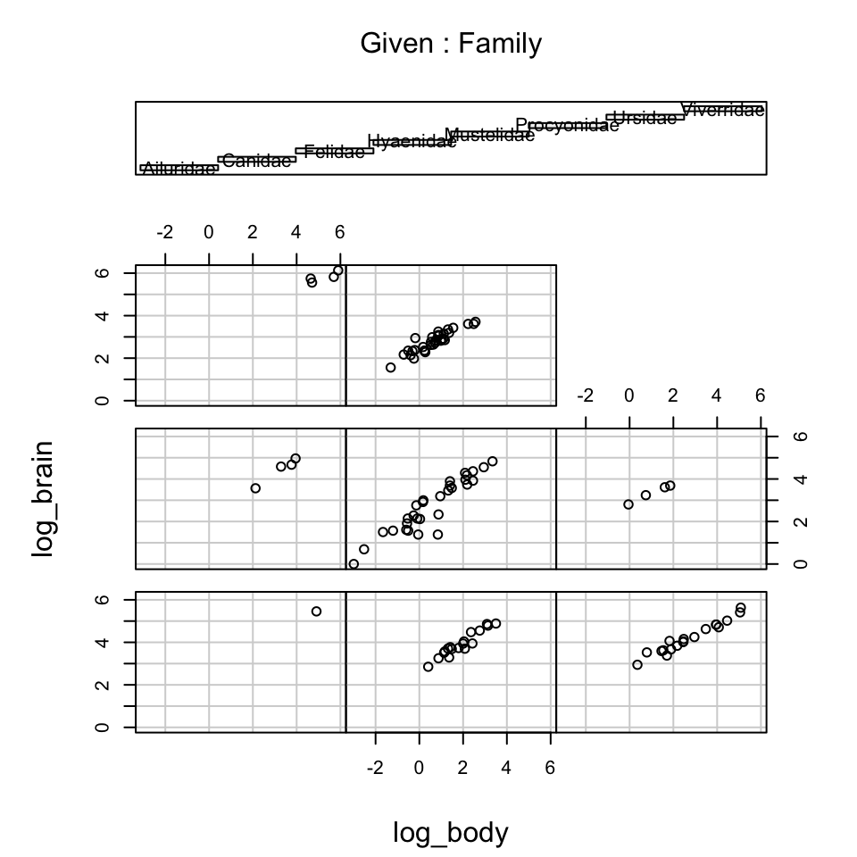

```r
coplot(log_brain ~ log_body | Family, data = carnivora)
```

## The `carnivora` dataset

### Two nested random effects:

```r
mod1 <- fitme(log_brain ~ log_body + (1|Family/Genus), data = carnivora, method = "REML")
mod1
```

```
## formula: log_brain ~ log_body + (1 | Family/Genus)
## REML: Estimation of lambda and phi by REML.
##       Estimation of fixed effects by ML.
## Family: gaussian ( link = identity )
##  ------------ Fixed effects (beta) ------------
##             Estimate Cond. SE t-value
## (Intercept)   2.5478  0.07196   35.40
## log_body      0.6113  0.02235   27.35
##  --------------- Random effects ---------------
## Family: gaussian ( link = identity )
##            --- Variance parameters ('lambda'):
## lambda = var(u) for u ~ Gaussian;
##    Genus:Fam.  :  0.02404
##    Family  :  0.01258
##              --- Coefficients for log(lambda):
##       Group        Term Estimate Cond.SE
##  Genus:Fam. (Intercept)   -3.728  0.3087
##      Family (Intercept)   -4.375  0.7868
## # of obs: 112; # of groups: Genus:Fam., 72; Family, 8
##  ------------- Residual variance  -------------
## Coefficients for log(phi) ~ 1 :
##             Estimate Cond. SE
## (Intercept)   -2.681   0.1527
## Estimate of phi=residual var:  0.0685
##  ------------- Likelihood values  -------------
##                         logLik
## p_v(h) (marginal L): -25.45760
##   p_beta,v(h) (ReL): -30.29721
```

## The `carnivora` dataset

### Two nested random effects:

```r
mod1bis <- fitme(log_brain ~ log_body + (1|Family) + (1|Family:Genus), data = carnivora, method = "REML")
mod1bis
```

```
## formula: log_brain ~ log_body + (1 | Family) + (1 | Family:Genus)
## REML: Estimation of lambda and phi by REML.
##       Estimation of fixed effects by ML.
## Family: gaussian ( link = identity )
##  ------------ Fixed effects (beta) ------------
##             Estimate Cond. SE t-value
## (Intercept)   2.5478  0.07196   35.40
## log_body      0.6113  0.02235   27.35
##  --------------- Random effects ---------------
## Family: gaussian ( link = identity )
##            --- Variance parameters ('lambda'):
## lambda = var(u) for u ~ Gaussian;
##    Family  :  0.01258
##    Family:Ge.  :  0.02404
##              --- Coefficients for log(lambda):
##       Group        Term Estimate Cond.SE
##      Family (Intercept)   -4.375  0.7868
##  Family:Ge. (Intercept)   -3.728  0.3087
## # of obs: 112; # of groups: Family, 8; Family:Ge., 72
##  ------------- Residual variance  -------------
## Coefficients for log(phi) ~ 1 :
##             Estimate Cond. SE
## (Intercept)   -2.681   0.1527
## Estimate of phi=residual var:  0.0685
##  ------------- Likelihood values  -------------
##                         logLik
## p_v(h) (marginal L): -25.45760
##   p_beta,v(h) (ReL): -30.29721
```

## The `carnivora` dataset

### Two nested random effects:

```r
mod1ter <- fitme(log_brain ~ log_body + (1|Family) + (1|Genus), data = carnivora, method = "REML")
mod1ter
```

```
## formula: log_brain ~ log_body + (1 | Family) + (1 | Genus)
## REML: Estimation of lambda and phi by REML.
##       Estimation of fixed effects by ML.
## Family: gaussian ( link = identity )
##  ------------ Fixed effects (beta) ------------
##             Estimate Cond. SE t-value
## (Intercept)   2.5478  0.07196   35.40
## log_body      0.6113  0.02235   27.35
##  --------------- Random effects ---------------
## Family: gaussian ( link = identity )
##            --- Variance parameters ('lambda'):
## lambda = var(u) for u ~ Gaussian;
##    Family  :  0.01258
##    Genus  :  0.02404
##              --- Coefficients for log(lambda):
##   Group        Term Estimate Cond.SE
##  Family (Intercept)   -4.375  0.7868
##   Genus (Intercept)   -3.728  0.3087
## # of obs: 112; # of groups: Family, 8; Genus, 72
##  ------------- Residual variance  -------------
## Coefficients for log(phi) ~ 1 :
##             Estimate Cond. SE
## (Intercept)   -2.681   0.1527
## Estimate of phi=residual var:  0.0685
##  ------------- Likelihood values  -------------
##                         logLik
## p_v(h) (marginal L): -25.45760
##   p_beta,v(h) (ReL): -30.29721
```

## The `ape::carnivora` dataset

### Two nested random effects:

- the formula `(1|Family/Genus)`
- the formula `(1|Family) + (1|Family:Genus)`
- the formula `(1|Family) + (1|Genus)`

are the same as long as genus are not being recycled between families!

## Checking the random structure

### You can check the Z matrices to make sure you did it right

```r
crossprod(as.matrix(mod1$ZAlist[[1]]))
```

[output not shown]

[output cut: 1040 more lines]

[output not shown]

## Checking the random structure

### You can check the Z matrices to make sure you did it right

```r
crossprod(as.matrix(mod1$ZAlist[[2]]))
```

```
##             Ailuridae Canidae Felidae Hyaenidae Mustelidae Procyonidae Ursidae Viverridae
## Ailuridae           1       0       0         0          0           0       0          0
## Canidae             0      18       0         0          0           0       0          0
## Felidae             0       0      19         0          0           0       0          0
## Hyaenidae           0       0       0         4          0           0       0          0
## Mustelidae          0       0       0         0         30           0       0          0
## Procyonidae         0       0       0         0          0           4       0          0
## Ursidae             0       0       0         0          0           0       4          0
## Viverridae          0       0       0         0          0           0       0         32
```

## Checking the random structure

### You can also use the `model.matrix` clone from `lme4`:

```r
lF <- lFormula(log_brain ~ log_body + (1|Family) + (1|Genus), data = carnivora)
lF$reTrms$flist  ## list of grouping factors used in the random-effects terms; see ?mkReTrms
```

```
## $Genus
##   [1] Canis        Canis        Canis        Canis        Lycaon       Cuon         Alopex       Vulpes
##   [9] Vulpes       Vulpes       Fennecus     Otocyon      Urocyon      Dusicyon     Dusicyon     Cerdocyon
##  [17] Chrysocyon   Speothos     Ursus        Ursus        Thalarctos   Selenarctos  Bassariscus  Polos
##  [25] Nasua        Procyon      Ailuropoda   Mustela      Mustela      Mustela      Mustela      Mustela
##  [33] Mustela      Mustela      Mustela      Mustela      Vormela      Martes       Martes       Martes
##  [41] Martes       Gulo         Tavra        Grison       Ictonyx      Poecilogale  Mellivora    Meles
##  [49] Taxidea      Mephistis    Spilogale    Lutra        Lutra        Lutra        Lutrogale    Aonyx
##  [57] Enhydra      Viverra      Civettictis  Viverricula  Genetta      Genetta      Prionodon    Nandinia
##  [65] Actogalidia  Paradoxurus  Paradoxurus  Paguma       Acrctictis   Hemigalus    Fossa        Eupleres
##  [73] Galidea      Herpetes     Herpetes     Herpetes     Herpetes     Herpetes     Herpetes     Herpetes
##  [81] Herpetes     Mungos       Crossarchus  Helogale     Ichneumia    Atilax       Cynictus     Paracynictis
##  [89] Suricata     Hyaena       Hyaena       Crocuta      Proteles     Felis        Felis        Felis
##  [97] Leptailurus  Prionailurus Prionailurus Prionailurus Caracal      Puma         Leopardus    Leopardus
## [105] Lynx         Lynx         Panthera     Panthera     Panthera     Panthera     Panthera     Acinonyx
```

[output cut: 20 more lines]

## Checking the random structure

### You can also check the BLUPs structure

```r
lapply(ranef(mod1), head, n = 20)
```

```
## $`( 1 | Genus:Family )`
##        Acinonyx:Felidae   Acrctictis:Viverridae  Actogalidia:Viverridae    Ailuropoda:Ailuridae          Alopex:Canidae
##            -0.085205035            -0.073166906             0.034670121            -0.020535219             0.045558423
##        Aonyx:Mustelidae       Atilax:Viverridae Bassariscus:Procyonidae           Canis:Canidae         Caracal:Felidae
##             0.064114556             0.033177240             0.060572878             0.044930898            -0.008317854
##       Cerdocyon:Canidae      Chrysocyon:Canidae  Civettictis:Viverridae       Crocuta:Hyaenidae  Crossarchus:Viverridae
##            -0.011824150             0.048745859            -0.086116694             0.010292179            -0.079250454
##            Cuon:Canidae     Cynictus:Viverridae        Dusicyon:Canidae      Enhydra:Mustelidae     Eupleres:Viverridae
##             0.047685435             0.062665088             0.027842386             0.073173547            -0.011100632
##
## $`( 1 | Family )`
##     Ailuridae       Canidae       Felidae     Hyaenidae    Mustelidae   Procyonidae       Ursidae    Viverridae
## -0.0107505656  0.1352927949 -0.0007966439 -0.0364960255 -0.0406946908  0.0537065684  0.0251604621 -0.1254218996
```

## Estimating the variances of two subgroups

### Two variances between genus

```r
carnivora$Canidae  <- as.numeric(carnivora$Family == "Canidae")
carnivora$Others   <- as.numeric(carnivora$Family != "Canidae")

mod2 <- fitme(log_brain ~ log_body + (0 + Canidae|Genus) + (0 + Others|Genus), data = carnivora, method = "REML")
```

Note: it does not seem to work with more than 2 variances, which I don't understand…

## Estimating the variances of two subgroups

```r
mod2
```

```
## formula: log_brain ~ log_body + (0 + Canidae | Genus) + (0 + Others |
##     Genus)
## REML: Estimation of lambda and phi by REML.
##       Estimation of fixed effects by ML.
## Family: gaussian ( link = identity )
##  ------------ Fixed effects (beta) ------------
##             Estimate Cond. SE t-value
## (Intercept)   2.5045  0.04756   52.66
## log_body      0.6269  0.02049   30.59
##  --------------- Random effects ---------------
## Family: gaussian ( link = identity )
##            --- Variance parameters ('lambda'):
## lambda = var(u) for u ~ Gaussian;
##    Genus  :  0.0227
##    Genus.1  :  0.02941
##              --- Coefficients for log(lambda):
##    Group    Term Estimate Cond.SE
##    Genus Canidae   -3.785  0.7588
##  Genus.1  Others   -3.527  0.3165
## # of obs: 112; # of groups: Genus, 72; Genus.1, 72
##  ------------- Residual variance  -------------
## Coefficients for log(phi) ~ 1 :
##             Estimate Cond. SE
## (Intercept)   -2.615    0.152
## Estimate of phi=residual var:  0.0732
##  ------------- Likelihood values  -------------
##                         logLik
## p_v(h) (marginal L): -27.10209
##   p_beta,v(h) (ReL): -32.52875
## lambda leverages numerically 1 were replaced by 1 - 1e-8
```

## Estimating the variances of two subgroups

```r
as.data.frame(ranef(mod2))
```

```
##              X..0...Canidae...Genus.. X..0...Others...Genus..
## Acinonyx                   0.00000000            -0.100037070
## Acrctictis                 0.00000000            -0.115725965
## Actogalidia                0.00000000             0.010802055
## Ailuropoda                 0.00000000            -0.035255561
## Alopex                     0.07949981             0.000000000
## Aonyx                      0.00000000             0.058321376
## Atilax                     0.00000000             0.007219962
## Bassariscus                0.00000000             0.094860444
## Canis                      0.11918919             0.000000000
## Caracal                    0.00000000            -0.007948453
## Cerdocyon                  0.02488589             0.000000000
## Chrysocyon                 0.07512192             0.000000000
## Civettictis                0.00000000            -0.129662982
## Crocuta                    0.00000000            -0.004357722
## Crossarchus                0.00000000            -0.112179008
## Cuon                       0.07554198             0.000000000
## Cynictus                   0.00000000             0.047885734
## Dusicyon                   0.08381596             0.000000000
## Enhydra                    0.00000000             0.066535027
## Eupleres                   0.00000000            -0.039099484
## Felis                      0.00000000             0.055661544
## Fennecus                   0.02177808             0.000000000
## Fossa                      0.00000000             0.032292643
## Galidea                    0.00000000             0.002041123
## Genetta                    0.00000000            -0.110836867
## Grison                     0.00000000             0.024918416
## Gulo                       0.00000000             0.092298056
## Helogale                   0.00000000            -0.035986156
## Hemigalus                  0.00000000             0.159554076
## Herpetes                   0.00000000            -0.068713607
## Hyaena                     0.00000000            -0.039431017
## Ichneumia                  0.00000000            -0.047468122
## Ictonyx                    0.00000000            -0.016706587
## Leopardus                  0.00000000             0.139735932
## Leptailurus                0.00000000            -0.001975349
## Lutra                      0.00000000             0.057328703
## Lutrogale                  0.00000000             0.088256202
## Lycaon                     0.09883854             0.000000000
## Lynx                       0.00000000             0.068067447
```

[output cut: 18 more lines]

```
## Proteles                   0.00000000            -0.077473894
## Puma                       0.00000000            -0.042077438
## Selenarctos                0.00000000             0.094501785
## Speothos                  -0.02528540             0.000000000
## Spilogale                  0.00000000            -0.149116621
## Suricata                   0.00000000             0.007139188
## Tavra                      0.00000000             0.041445256
## Taxidea                    0.00000000             0.146291387
## Thalarctos                 0.00000000            -0.020922278
## Urocyon                    0.09089458             0.000000000
## Ursus                      0.00000000            -0.033495849
## Viverra                    0.00000000            -0.083568625
## Viverricula                0.00000000            -0.084961919
## Vormela                    0.00000000            -0.176448866
## Vulpes                     0.14113439             0.000000000
```

## Estimating the variances of two subgroups

### Same using `lme4`

```r
mod2_lme4 <- lmer(log_brain ~ log_body + (0 + Canidae|Genus) + (0 + Others|Genus), data = carnivora)
lapply(VarCorr(mod2_lme4), function(r) attr(r, "stddev")^2)
```

```
## $Genus
##   Canidae
## 0.0226997
##
## $Genus.1
##     Others
## 0.02940733
```

```r
head(ranef(mod2_lme4))
```

```
## $Genus
##                  Canidae       Others
## Acinonyx      0.00000000 -0.100036880
## Acrctictis    0.00000000 -0.115725430
## Actogalidia   0.00000000  0.010801495
## Ailuropoda    0.00000000 -0.035256137
## Alopex        0.07948985  0.000000000
## Aonyx         0.00000000  0.058320076
## Atilax        0.00000000  0.007219385
## Bassariscus   0.00000000  0.094859132
## Canis         0.11917954  0.000000000
## Caracal       0.00000000 -0.007949012
## Cerdocyon     0.02488243  0.000000000
## Chrysocyon    0.07511229  0.000000000
## Civettictis   0.00000000 -0.129662295
## Crocuta       0.00000000 -0.004358500
## Crossarchus   0.00000000 -0.112178231
## Cuon          0.07553233  0.000000000
## Cynictus      0.00000000  0.047884960
## Dusicyon      0.08380707  0.000000000
## Enhydra       0.00000000  0.066533595
## Eupleres      0.00000000 -0.039099516
## Felis         0.00000000  0.055660148
## Fennecus      0.02177514  0.000000000
## Fossa         0.00000000  0.032291897
## Galidea       0.00000000  0.002040784
## Genetta       0.00000000 -0.110836644
## Grison        0.00000000  0.024917700
## Gulo          0.00000000  0.092296467
## Helogale      0.00000000 -0.035985971
## Hemigalus     0.00000000  0.159552116
## Herpetes      0.00000000 -0.068714401
## Hyaena        0.00000000 -0.039431901
## Ichneumia     0.00000000 -0.047468143
## Ictonyx       0.00000000 -0.016706727
## Leopardus     0.00000000  0.139733974
## Leptailurus   0.00000000 -0.001975970
## Lutra         0.00000000  0.057327235
## Lutrogale     0.00000000  0.088254689
## Lycaon        0.09882607  0.000000000
```

[output cut: 19 more lines]

```
## Proteles      0.00000000 -0.077473699
## Puma          0.00000000 -0.042077828
## Selenarctos   0.00000000  0.094499908
## Speothos     -0.02528285  0.000000000
## Spilogale     0.00000000 -0.149115360
## Suricata      0.00000000  0.007138810
## Tavra         0.00000000  0.041444307
## Taxidea       0.00000000  0.146289371
## Thalarctos    0.00000000 -0.020923122
## Urocyon       0.09088324  0.000000000
## Ursus         0.00000000 -0.033497096
## Viverra       0.00000000 -0.083568380
## Viverricula   0.00000000 -0.084961508
## Vormela       0.00000000 -0.176447335
## Vulpes        0.14112207  0.000000000
```

## Random slopes

## Fitting a random slope model

```r
(mod3 <- fitme(log_brain ~ log_body + (log_body|Family) + (1|Genus), data = carnivora, method = "REML"))
```

```
## formula: log_brain ~ log_body + (log_body | Family) + (1 | Genus)
## REML: Estimation of lambda, phi, corrPars and ranCoefs by REML.
##       Estimation of fixed effects by ML.
## Family: gaussian ( link = identity )
##  ------------ Fixed effects (beta) ------------
##             Estimate Cond. SE t-value
## (Intercept)   2.5889  0.09622    26.9
## log_body      0.5991  0.03256    18.4
##  --------------- Random effects ---------------
## Family: gaussian ( link = identity )
##          --- Random-coefficients Cov matrices:
##   Group        Term     Var.   Corr.
##  Family (Intercept)  0.03177
##  Family    log_body 0.003289 -0.6947
##            --- Variance parameters ('lambda'):
## lambda = var(u) for u ~ Gaussian;
##    Genus  :  0.01493
##              --- Coefficients for log(lambda):
##  Group        Term Estimate Cond.SE
##  Genus (Intercept)   -4.204  0.3743
## # of obs: 112; # of groups: Family, 16; Genus, 72
##  ------------- Residual variance  -------------
## Coefficients for log(phi) ~ 1 :
##             Estimate Cond. SE
## (Intercept)   -2.661   0.1492
## Estimate of phi=residual var:  0.0699
##  ------------- Likelihood values  -------------
##                         logLik
## p_v(h) (marginal L): -24.85503
##   p_beta,v(h) (ReL): -29.19870
```

## The BLUPs for the slopes

```r
ranef(mod3)$`( log_body | Family )`
```

```
##              (Intercept)      log_body
## Ailuridae    0.001722951 -0.0050825177
## Canidae      0.112748300  0.0136381129
## Felidae      0.130728783 -0.0543206189
## Hyaenidae   -0.045538094 -0.0003843347
## Mustelidae  -0.155303707  0.0688315114
## Procyonidae  0.087614023 -0.0200190198
## Ursidae      0.024080600  0.0046673049
## Viverridae  -0.156052857 -0.0073304381
```

## Predictions

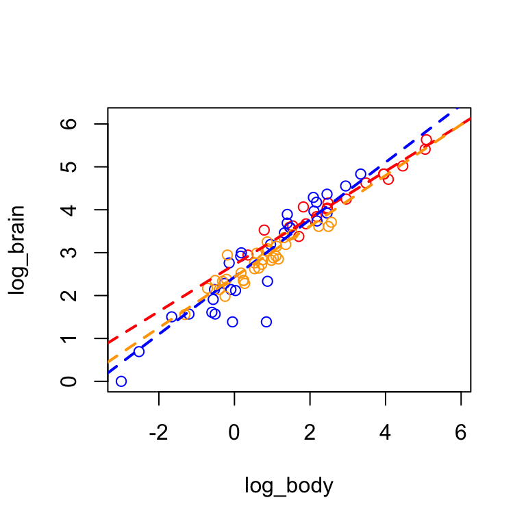

```r
plot(log_brain ~ log_body, data = subset(carnivora, Family == "Felidae"), col = "red",
     ylim = range(carnivora$log_brain), xlim = range(carnivora$log_body))
points(log_brain ~ log_body, data = subset(carnivora, Family == "Mustelidae"), col = "blue")
points(log_brain ~ log_body, data = subset(carnivora, Family == "Viverridae"), col = "orange")
abline(mod3$fixef + ranef(mod3)$`( log_body | Family )`["Felidae", ], col = "red", lwd = 2, lty = 2)
abline(mod3$fixef + ranef(mod3)$`( log_body | Family )`["Mustelidae", ], col = "blue", lwd = 2, lty = 2)
abline(mod3$fixef + ranef(mod3)$`( log_body | Family )`["Viverridae", ], col = "orange", lwd = 2, lty = 2)
```

## Practice

Perform the predictions of all slopes using the function predict instead, both using `spaMM` and `lme4`.

## Testing if slopes differ between families

### `lme4`

```r
mod4 <- lmer(log_brain ~ log_body + (log_body|Family) + (1|Genus), data = carnivora, REML = TRUE)
mod4noRS <- lmer(log_brain ~ log_body + (1|Family) + (1|Genus), data = carnivora, REML = TRUE)
anova(mod4, mod4noRS) ## count 2 DF as covariance is included... correct?
```

```
## refitting model(s) with ML (instead of REML)
```

```
## Data: carnivora
## Models:
## mod4noRS: log_brain ~ log_body + (1 | Family) + (1 | Genus)
## mod4: log_brain ~ log_body + (log_body | Family) + (1 | Genus)
##          Df    AIC    BIC  logLik deviance  Chisq Chi Df Pr(>Chisq)
## mod4noRS  5 60.799 74.392 -25.399   50.799
## mod4      7 63.497 82.526 -24.748   49.497 1.3024      2     0.5214
```

## Testing if slopes differ between families

### `spaMM`

```r
mod3noRS <- fitme(log_brain ~ log_body + (1|Family) + (1|Genus), data = carnivora, method = "REML")
pchisq(2*(logLik(mod3) - logLik(mod3noRS)), df = 2, lower.tail = FALSE) ## count 2 DF to include covariance as lme4
```

```
##      p_bv
## 0.3333673
```

## Testing if slopes differ between families

### LM

```r
mod5 <- lm(log_brain ~ log_body * Family + Genus, data = carnivora)
mod5noIS <- lm(log_brain ~ log_body + Family + Genus, data = carnivora)
anova(mod5, mod5noIS)
```

```
## Analysis of Variance Table
##
## Model 1: log_brain ~ log_body * Family + Genus
## Model 2: log_brain ~ log_body + Family + Genus
##   Res.Df    RSS Df Sum of Sq     F Pr(>F)
## 1     34 2.5466
## 2     39 2.7683 -5  -0.22169 0.592 0.7061
```

## Fitting uncorrelated random intercept and slope

```r
(mod3_alt <- fitme(log_brain ~ log_body + (1|Family)  + (0 + log_body|Family) + (1|Genus), data = carnivora))
```

```
## formula: log_brain ~ log_body + (1 | Family) + (0 + log_body | Family) +
##     (1 | Genus)
## ML: Estimation of lambda and phi by ML.
##     Estimation of fixed effects by ML.
## Family: gaussian ( link = identity )
##  ------------ Fixed effects (beta) ------------
##             Estimate Cond. SE t-value
## (Intercept)   2.5422  0.06622   38.39
## log_body      0.6132  0.02526   24.28
##  --------------- Random effects ---------------
## Family: gaussian ( link = identity )
##            --- Variance parameters ('lambda'):
## lambda = var(u) for u ~ Gaussian;
##    Family  :  0.008958
##    Family.1  :  0.001057
##    Genus  :  0.01899
##              --- Coefficients for log(lambda):
##     Group        Term Estimate Cond.SE
##    Family (Intercept)   -4.715  0.8161
##  Family.1    log_body   -6.853  0.9065
##     Genus (Intercept)   -3.964  0.3345
## # of obs: 112; # of groups: Family, 8; Family.1, 8; Genus, 72
##  ------------- Residual variance  -------------
## Coefficients for log(phi) ~ 1 :
##             Estimate Cond. SE
## (Intercept)   -2.679   0.1502
## Estimate of phi=residual var:  0.06866
##  ------------- Likelihood values  -------------
##                         logLik
## p_v(h) (marginal L): -25.11157
```

## Fitting uncorrelated random intercept and slope

```r
mod4_alt <- lmer(log_brain ~ log_body + (1|Family)  + (0 + log_body|Family) + (1|Genus), data = carnivora, REML = FALSE)
lapply(VarCorr(mod4_alt), function(r) attr(r, "stddev")^2)
```

```
## $Genus
## (Intercept)
##  0.01898316
##
## $Family
##    log_body
## 0.001057458
##
## $Family.1
## (Intercept)
## 0.008958115
```

## Fitting uncorrelated random intercept and slope

```r
mod4_alt_bis <- lmer(log_brain ~ log_body + (log_body||Family) + (1|Genus), data = carnivora, REML = FALSE)
lapply(VarCorr(mod4_alt_bis), function(r) attr(r, "stddev")^2)
```

```
## $Genus
## (Intercept)
##  0.01898316
##
## $Family
##    log_body
## 0.001057458
##
## $Family.1
## (Intercept)
## 0.008958115
```

Note 1: the syntax `||` does not work in `spaMM` but it is just a shortcut, so it is not really needed.

Note 2: unless you have a very good reason not to, you should consider the correlations between random effects!

## What you need to remember

- when to consider effects as fixed or random
- that REML fits are best to study variances
- how to implement different random effects structure
- what random slopes are

## Table of contents

## Mixed-effects models

- 4.0 Introduction to LMM
- 4.1 Random effects
- 4.2 Solving LM problems using LMM
- 4.3 A showcase of some useful applications
- 4.4 Introduction to GLMM
- 4.5 More complex mixed models